# International Exposure and English Ability

Raj Mehta - rajm

```r
lang_data <- read_csv("language_data.csv")
```

### Introduction

The data set given is a subset of the which English data, which records multiple variables about a participant in an English test.

The questions I seek to answer regard international exposure and English language ability. By international exposure I specifically want to look at factors such as total known languages and places lived by a person, and their effect on English ability. Ability in English language will always be measured by the percentage of correct answers on the test.

To answer the first part of my question, I will be looking at if people who have a spent a portion of their lives outside an English speaking country are better at English than those who have spent their entire life in an English speaking country. The people that I will be looking at are those that have English as their native language. The variable that I will use to help me with this analysis is ‘english_country_percent.’

Answering a similar question, I will take my analysis one step further to see if there is a correlation between the number of countries someone has lived (do not necessarily have to be English speaking countries) and their English ability. For that I will edit my tibble so that I can get a numerical value for the variable ‘all_countries.’

To answer the second part of my research question, I will be performing statistical tests to see whether people that speak only English have better English ability than those that are multilingual (with English being one of their known languages).

### Exploratory data analysis

```r
#new tibble created with number of primary languages and number of countries lived.

langNum <- lang_data %>%
  filter(native_english) %>%
  mutate(langs = str_count(primary_languages, ",") + 1) %>%
  mutate(countries = str_count(all_countries, ",") + 1) %>%
  mutate(one_plus = langs > 1) %>%
  mutate(id = row_number())


#tibble to answer question one, tells us if someone has lived only in English speaking countries or not

other_country <- lang_data %>%
  filter(native_english) %>%
  mutate(stayed = english_country_percent >= 1) %>%
  mutate(id = row_number())



other_country %>%
  group_by(stayed)%>%
  summarise(mean_score = mean(correct))
```

```
## # A tibble: 2 x 2
##   stayed mean_score
## * <lgl>       <dbl>
## 1 FALSE       0.891
## 2 TRUE        0.959
```

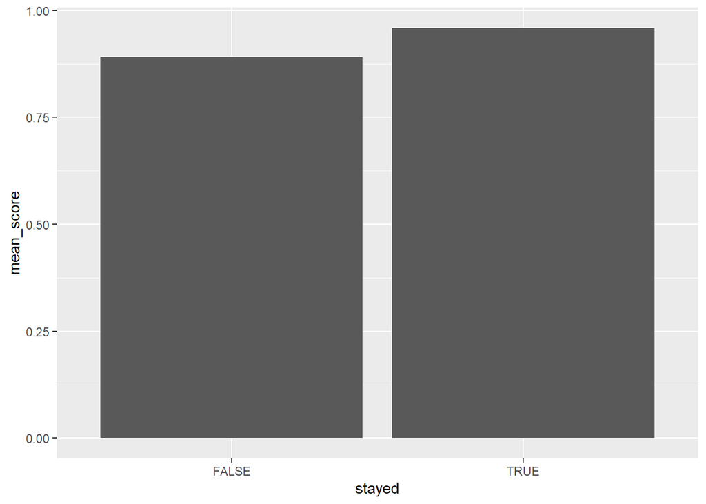

```r
#ot is the same tibble as other_country just helped with graphing.

ot <- other_country %>%
  group_by(stayed)%>%
  summarise(mean_score = mean(correct))

#This column graph compares people that have moved (lived in a non-english speaking country) versus those that have stayed in only English speaking countries
ggplot(ot, aes(x = stayed, y = mean_score)) +
  geom_col()
```

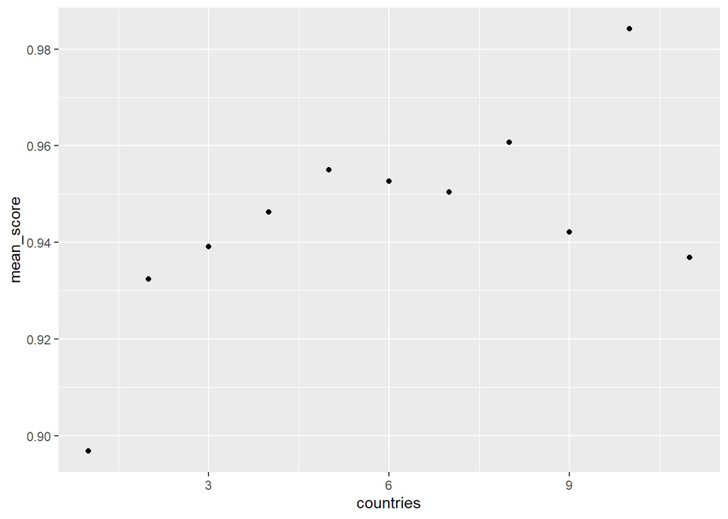

```r
#Mean scores3 compares the number of known languages with the mean score.
meanScores3 <- langNum %>%
  group_by(countries) %>%
  summarize(mean_score = mean(correct))

ggplot(meanScores3, aes(x = countries, y = mean_score)) +
  geom_point()
```

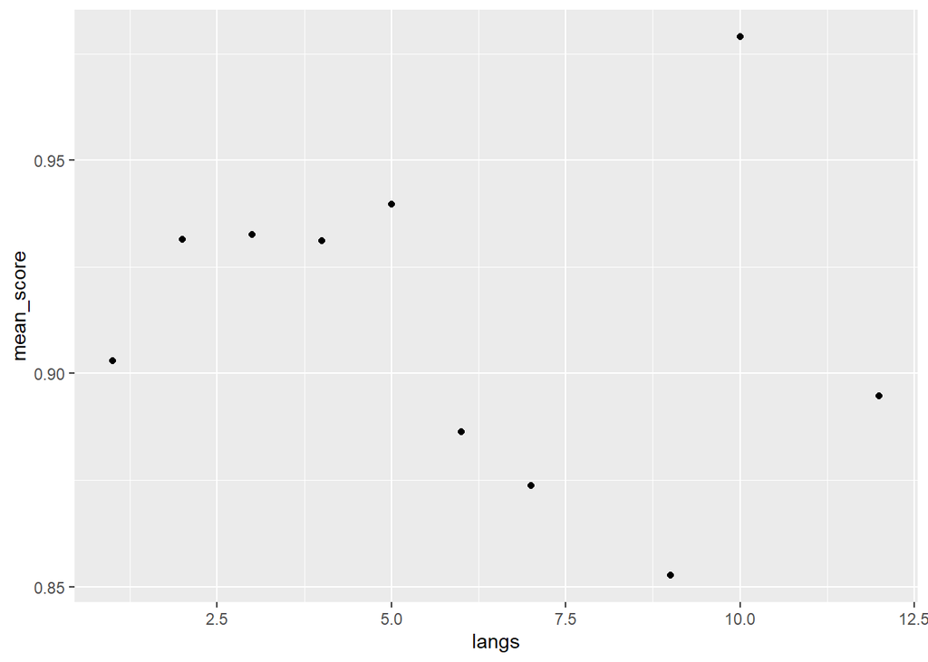

```r
#meanScores is mean scores based on how many languages someone knows.
meanScores <- langNum %>%
  group_by(langs) %>%
  summarize(mean_score = mean(correct))

meanScoresL <- langNum %>%
  group_by(langs) %>%
  summarize(mean_score = mean(correct)) %>%
  pull(mean_score)


meanScores3L <- langNum %>%
  group_by(countries) %>%
  summarize(mean_score = mean(correct)) %>%
  pull(mean_score)

combine <- tibble(n = 1:10, y = meanScoresL, z = meanScores3L[1:10])




ggplot(meanScores, aes(x = langs, y = mean_score)) +
  geom_point()
```

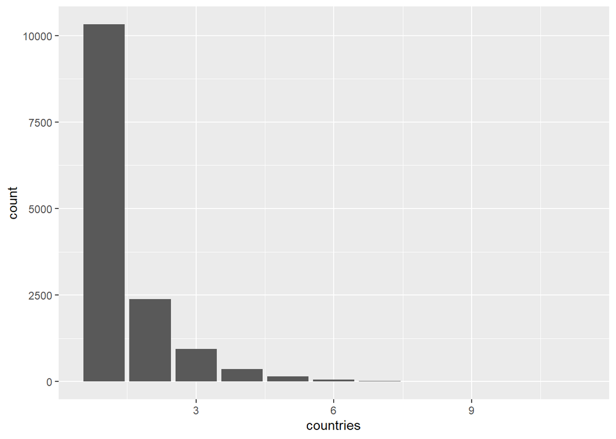

```r
ggplot(langNum, aes(x = countries, y = )) +
  geom_bar()
```

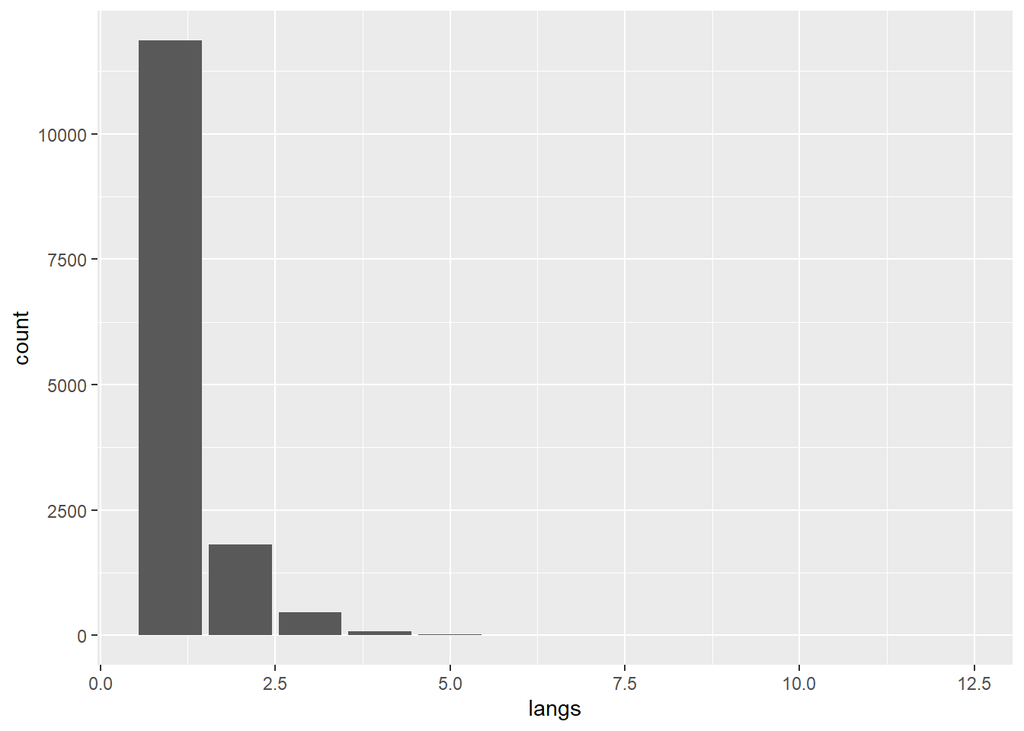

```r
ggplot(langNum, aes(x = langs, y = )) +
  geom_bar()
```

Description of the graphs.

1. The first column graph shows the mean score of those that have lived in a non-English speaking country (stayed = FALSE) versus those that have stayed in an English speaking country their whole life (stayed = TRUE). The graph shows that people who have lived in an English speaking country their whole life tend to perform better on the test.
2. The second graph is a scatter plot showing the mean score of a person versus how many different countries they live in. Despite the results of the first graph, there seems to be a weak positive correlation between the two variables.
3. The last graph is a scatter plot showing the number of languages a person knows and their English ability. I have grouped by known languages and used the mean, so this is not an entirely accurate description between the two variables, as there are many more people that know only one language as opposed to 5 languages. There does not seem to be a strong correlation between the variables, but we can find out if there is one through our inference tests and when building our model.

4, 5) Graphs 4 and 5 are histograms showing the distribution of number of countries lived and the distribution of number of languages known. As we can see, when we perform our inferences it is best to use samples because the data is very right skewed.

Moving on, we will check if our results are significant by performing various inference tests.

### Inference

The first inference test I perform is a t-test. I perform this t-test to see if there is a significant difference in English ability between English speakers that have lived only in English speaking countries versus those that have moved to a non-English speaking country. I do this since the bar graph suggests that there is a difference. Sampling is used because the histogram above shows that there are many more people who lived in only one country than those that have moved around.

```r
# count the number of people that have moved internationally.
# count number of people lived only in English speaking country

n_inter <- other_country %>%
  filter(!stayed) %>%
  pull(id)


n_stayed <- other_country %>%
  filter(stayed) %>%
  pull(id)

#take a sample here
inter.id <- sample(n_inter, 1000)

inter.sample <- other_country %>%
  filter(id %in% inter.id)%>%
  pull(correct)

stayed.id <- sample(n_stayed, 1000)

stayed.sample <- other_country %>%
  filter(id %in% stayed.id) %>%
  pull(correct)

t.test(inter.sample, stayed.sample)
```

```
##
##  Welch Two Sample t-test
##
## data:  inter.sample and stayed.sample
## t = -24.023, df = 1498, p-value < 2.2e-16
## alternative hypothesis: true difference in means is not equal to 0
## 95 percent confidence interval:
##  -0.07108158 -0.06035000
## sample estimates:
## mean of x mean of y
## 0.8944000 0.9601158
```

The results of this t-test show that there is a significant difference between those who have lived in only English speaking places and those that have moved around. Moreover, it tells us that people that have lived their whole life in an English speaking country have a better score than those that have moved out of an English speaking country.

Next I perform an anova test to see if there is a relationship between the number of countries someone has lived in and scores.

```r
oneway.test(formula = correct ~ countries, data = langNum)
```

```
##
##  One-way analysis of means (not assuming equal variances)
##
## data:  correct and countries
## F = 92.937, num df = 10.000, denom df = 15.966, p-value = 3.283e-12
```

As the p-value is very close to 0, I can conclude that the number of countries someone has lived in has an effect on average score. I will proceed to see what that relationship is in my modeling section.

The last inference test I perform is a t-test to see if there is a difference between people that speak only one language versus those that are multilingual. Again both groups of people are native English speakers and samples are taken because there are far more monolingual people than multilingual ones.

```r
#repeat t - test for one language or more than one language
one_plus <- langNum %>%
  filter(one_plus) %>%
  nrow()

one_only <- langNum %>%
  filter(!one_plus) %>%
  nrow()

one_plus.id <- sample(one_plus, 1000)

one_plus.sample <- langNum %>%
  filter(id %in% one_plus.id)%>%
  pull(correct)

one_only.id <- sample(one_only, 1000)

one_only.sample <- langNum %>%
  filter(id %in% one_only.id) %>%
  pull(correct)

t.test(one_plus.sample, one_only.sample)
```

```
##
##  Welch Two Sample t-test
##
## data:  one_plus.sample and one_only.sample
## t = 4.8518, df = 1963.4, p-value = 1.32e-06
## alternative hypothesis: true difference in means is not equal to 0
## 95 percent confidence interval:
##  0.009444784 0.022260480
## sample estimates:
## mean of x mean of y
## 0.9239474 0.9080947
```

The second t-test shows us that there is a significant difference and that people who speak more than one language (with English being one of them) have a higher average score than those that speak only English.

### Modeling

In my inferences I was able to conclude that the number of countries someone has lived in has an effect on the average score. I also found out that people who know multiple languages have higher scores than those who speak only English. For that reason I will create a linear model with score as a function of number of countries and languages known. As the data is heavily skewed, I will use samples as opposed to the data points from the entire data set.

```r
samp <- langNum %>%
  pull(id)

#take a sample here
samp.id <- sample(samp, 1000)

samp.sample <- langNum %>%
  filter(id %in% inter.id)


m1 <- lm(correct ~ countries + langs, data = samp.sample)

summary(m1)
```

```
##
## Call:
## lm(formula = correct ~ countries + langs, data = samp.sample)
##
## Residuals:
##      Min       1Q   Median       3Q      Max
## -0.28871 -0.03770  0.01493  0.05461  0.12019
##
## Coefficients:
##             Estimate Std. Error t value Pr(>|t|)
## (Intercept) 0.843842   0.005774 146.147  < 2e-16 ***
## countries   0.017002   0.002161   7.867 9.43e-15 ***
## langs       0.018961   0.003859   4.913 1.05e-06 ***
## ---
## Signif. codes:  0 '***' 0.001 '**' 0.01 '*' 0.05 '.' 0.1 ' ' 1
##
## Residual standard error: 0.07305 on 997 degrees of freedom
## Multiple R-squared:  0.09784,    Adjusted R-squared:  0.09603
## F-statistic: 54.07 on 2 and 997 DF,  p-value: < 2.2e-16
```

```r
m2 <- lm(correct ~ countries, data = samp.sample)

summary(m2)
```

```
##
## Call:
## lm(formula = correct ~ countries, data = samp.sample)
##
## Residuals:
##      Min       1Q   Median       3Q      Max
## -0.29937 -0.04140  0.01296  0.05334  0.11650
##
## Coefficients:
##             Estimate Std. Error t value Pr(>|t|)
## (Intercept) 0.864173   0.004073  212.17   <2e-16 ***
## countries   0.019327   0.002133    9.06   <2e-16 ***
## ---
## Signif. codes:  0 '***' 0.001 '**' 0.01 '*' 0.05 '.' 0.1 ' ' 1
##
## Residual standard error: 0.07389 on 998 degrees of freedom
## Multiple R-squared:  0.076,  Adjusted R-squared:  0.07508
## F-statistic: 82.09 on 1 and 998 DF,  p-value: < 2.2e-16
```

```r
m3 <- lm(correct ~ langs, data = samp.sample)

summary(m3)
```

```
##
## Call:
## lm(formula = correct ~ langs, data = samp.sample)
##
## Residuals:
##      Min       1Q   Median       3Q      Max
## -0.26659 -0.04553  0.01762  0.05973  0.11236
##
## Coefficients:
##             Estimate Std. Error t value Pr(>|t|)
## (Intercept) 0.862032   0.005450 158.179  < 2e-16 ***
## langs       0.025608   0.003879   6.602 6.58e-11 ***
## ---
## Signif. codes:  0 '***' 0.001 '**' 0.01 '*' 0.05 '.' 0.1 ' ' 1
##
## Residual standard error: 0.07524 on 998 degrees of freedom
## Multiple R-squared:  0.04185,    Adjusted R-squared:  0.04089
## F-statistic: 43.59 on 1 and 998 DF,  p-value: 6.583e-11
```

The model (m1) shows how English ability is affected by the number of countries a person has lived in and number of languages known. The p-value is under 0.05 for both variables and the r-squared value is 0.1. This suggests that their is a significant but weak correlation between the variables. As the gradient is positive for both variables this correlation is positive.

I then performed linear analysis on the variables alone (backward analysis, shown by summaries of m2 and m3). When removing either one of the variables, the resulting model has a much lower r-squared and adjusted r-squared value. This suggests that the best model we should use is the one that has score as a function of both number of languages known and countries lived.

### Conclusion

To conclude, I will attempt to provide explanations for our observed data and highlight any shortcomings in the data set and in my research. From the inferences we learned that people who have stayed in English speaking countries their whole life have higher scores than those that have not. This makes sense as people who live in an English speaking country will be exposed to English more often.

I then learned that native English speakers that know more than one language are better at English than those who know only one language. This may be because multilingual people have a better understanding of language in general and are therefore able to better perform on the test.

I then created a model to see how both number of countries lived in and number of languages known influences score. We found that there was a weak positive correlation between both variables. This is quite an interesting result and it makes sense as people who live in multiple countries probably speak multiple languages and thus both variables would correlate similarly with test scores. The accuracy of our model was quite low as the R-squared value was very low and if we were to make predictions about a person that knows many languages or has lived in many places, our model would tell us that the score should be above 1 which is not possible.

The findings I have collected have helped me answer my research questions and tell us that different types of international exposure affect English ability in different ways.

A shortcoming in our data is that we had very few people that lived in many countries or spoke many languages (8 or more). This meant our dataset was not quite complete and the statistical tests became inaccurate as there were certain data points where we were using data of thousands of people and others where we had data of only a handful of people. For example, there were more than ten thousand people that knew 1 language but less than a 100 people that knew 4 languages. If we had data from more of these kind of people (outliers) it may help us. Furthermore there were many variables that we did not control for. For example, level of education could have been an important factor in judging English ability, and the samples could have had an uneven distribution of education levels. Age and Age of starting to learn English could have also had a similar effect.